# Lab 1: Linear models for quantitative genetics

BMI 206

Isobel Beasley

Due: 18th October 20224

## PART1: Analyzing provided genotype and phenotype data.

### Read in the genotype and phenotype matrices.

```r
genos = as.matrix(read.table(here::here("gwas/genos.txt")))
phenos = as.matrix(read.table(here::here("gwas/phenos.txt")))
```

### Make a histogram of the phenotypes. Do they look normally distributed?

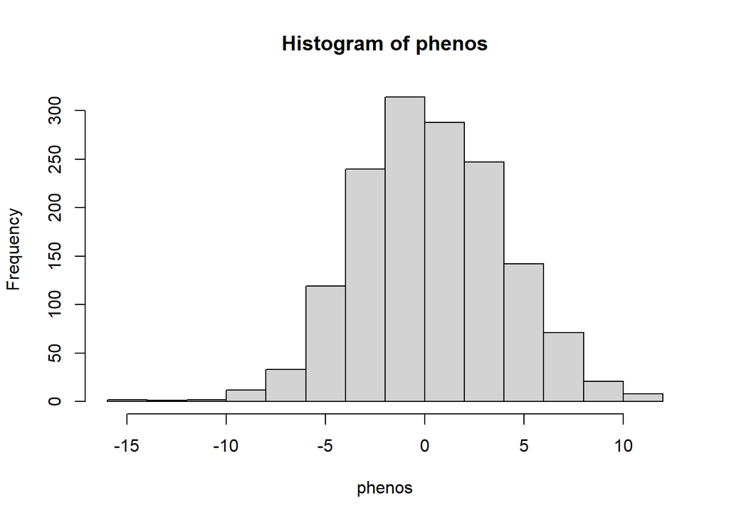

```r
hist(phenos)
```

```r
mean(phenos)
```

```
## [1] 0.3324209
```

```r
median(phenos)
```

```
## [1] 0.1916919
```

Additionally, the tails of this distribution do not appear particularly ‘fat’, meaning the distribution is likely better approximated by a normal distribution than a t-distribution.

### How are the genotypes encoded?

```r
table(genos)
```

```
## genos
##       0       1       2
## 4773842 5447131 4779027
```

The genotypes are encoded such that the heterozygous genotype for each snp is 1, the homogyzous genotypes are encoded as 2 or 0, depending on which allele is consider the reference at each locus.

### How many individuals are there in the dataset and how many SNPs? (Save them in `N` and `M`, respectively.)

```r
dim(genos)
```

```
## [1]  1500 10000
```

```r
dim(phenos)
```

```
## [1] 1500    1
```

```r
N = length(phenos)
N # number of individuals
```

```
## [1] 1500
```

```r
M = ncol(genos)
M # number of SNPs
```

```
## [1] 10000
```

### **Compute the *minor* allele frequency for every SNP. Check MAFs are <0.5.**

```r
MAFs = array(0,M)

for(i in 1:M) {
      MAFs[i] = sum(genos[,i]) / (2*N)

      # checking that MAF<0.5
      # if major allele freq was calculated, then
      # take minor allele freq as 1-allele freq
      # if(MAFs[i]>0.5){
      #   MAFs[i] = 1-MAFs[i]
      # }

      MAFs[i] = min(MAFs[i], 1-MAFs[i])

}

# out of interest, this was the fastest approach I tried
# MAFs = colSums(genos) / (2*N)
# MAFs = ifelse(MAFs > 0.5, 1-MAFs, MAFs)

length(MAFs) # check that it was calculated for the right number of snps
```

```
## [1] 10000
```

```r
MAFs[1:10] # how does the MAF look for the first 10 snps
```

```
##  [1] 0.1516667 0.3226667 0.4126667 0.2156667 0.4626667 0.4826667 0.4863333
##  [8] 0.1516667 0.2990000 0.3310000
```

```r
max(MAFs)
```

```
## [1] 0.5
```

### **Run a GWAS under an additive model and save the p-values, z-scores, and effect sizes.**

```r
pvalues = array(0,M)
zscores = array(0,M)
betas = array(0,M)

for(i in 1:M) {
    g = genos[,i]
    # under an additive model means, without considering possible dominance / recessives
    res = summary(lm(phenos~g))
    zscores[i] = res$coefficients[2,"t value"]
    pvalues[i] = res$coefficients[2,"Pr(>|t|)"]
    betas[i] = res$coefficients[2,"Estimate"]
}
```

### Summarize the effect sizes.

```r
summary(betas)
```

```
##      Min.   1st Qu.    Median      Mean   3rd Qu.      Max.
## -3.400728 -0.105822  0.002475  0.004204  0.113524  2.245525
```

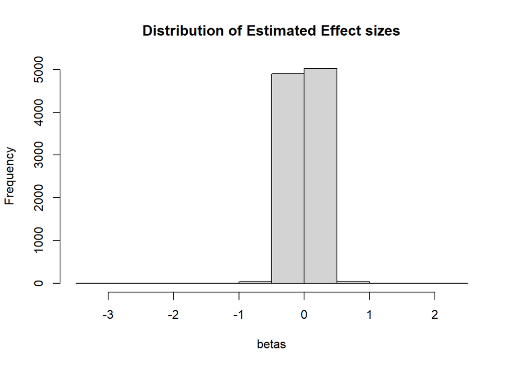

```r
hist(betas, breaks = 20, main = "Distribution of Estimated Effect sizes")
```

Most effect sizes are very close to zero (very small). Positve and ne Effect sizes are roughly equally likely to be positive, as the are negative (when all snps are considered).

### Are there any significantly associated SNPs? If so, which SNPs are they?

```r
sig_thresh = 0.05 / M #bonferroni corrected significance test
assoc = which(pvalues<sig_thresh)
assoc # the first 10 snps are the significantly associated sns
```

```
##  [1]  1  2  3  4  5  6  7  8  9 10
```

### How big are their effect sizes? How significant are they?

```r
betas[assoc]
```

```
##  [1] -3.4007282  2.1340404  1.5238919  0.7930685 -1.4787008  1.9852459
##  [7] -1.2225227  2.2455246  1.8605128  0.7607997
```

```r
abs(betas[assoc]) # this is how big their effect sizes are
```

```
##  [1] 3.4007282 2.1340404 1.5238919 0.7930685 1.4787008 1.9852459 1.2225227
##  [8] 2.2455246 1.8605128 0.7607997
```

```r
zscores[assoc] # zscores tell you about significance - but more importantly
```

```
##  [1] -21.021900  16.013141  11.615036   5.003065 -11.436804  16.128209
##  [7]  -9.115941  12.602187  13.341784   5.383964
```

```r
pvalues[assoc] # the p-values tell you how significant they are ... pretty significant, which makes sense given we use the more conservative bonferroni correction
```

```
##  [1] 3.488001e-86 2.148840e-53 6.341996e-30 6.308608e-07 4.244077e-29
##  [6] 4.411319e-54 2.434694e-19 1.103317e-34 1.884171e-38 8.447687e-08
```

### Draw a QQ plot for log10(p) values.

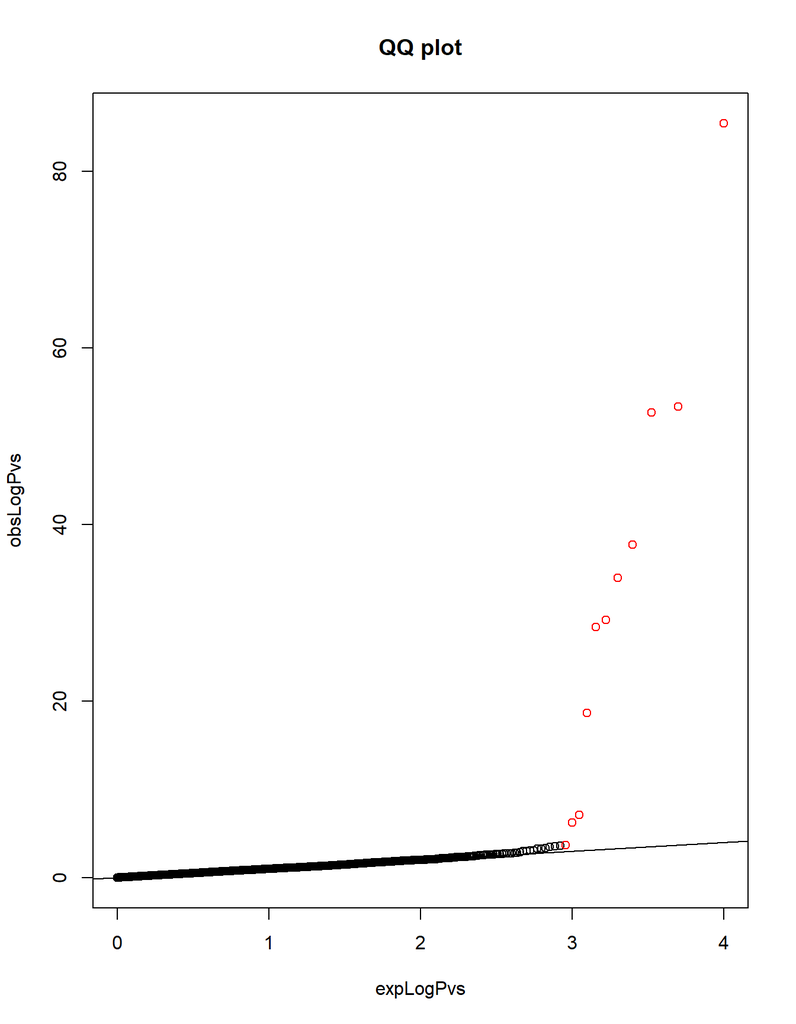

```r
obsLogPvs = sort(-log10(pvalues))
expLogPvs = sort(-log10(seq(1/M,1,1/M)))
plot(expLogPvs,obsLogPvs,main='QQ plot')
abline( a=0, b=1 )
#label the significant SNPs red
points(expLogPvs[(M-length(assoc)):M],obsLogPvs[(M-length(assoc)):M],col="red")
```

### Is there inflation? Use the chi-square statistics to check.

```r
chis = zscores^2
lambdaGC = median(chis)/0.454 # why .454?
# .454 =  qchisq(0.5, 1), the median of chisquared distribution with 1 degree of freedom (i.e. the median of null distribution)
lambdaGC
```

```
## [1] 1.007873
```

```r
# this value is close to 1, suggestive of no inflation
```

### Plot the phenotype predictions for the most significant SNP.

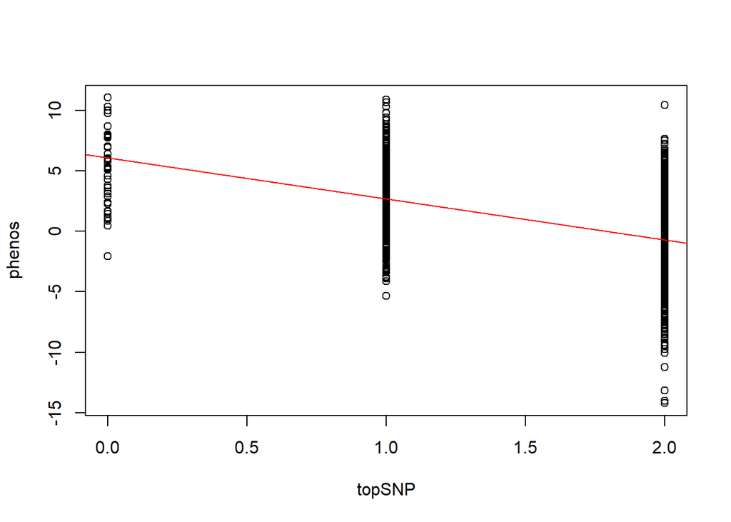

```r
topSNP = genos[,order(pvalues)[1]]
plot(topSNP,phenos)
abline(lm(phenos~topSNP)$coeff,col="red")
```

### **Build a linear predictor of the phenotype using the associated SNPs.**

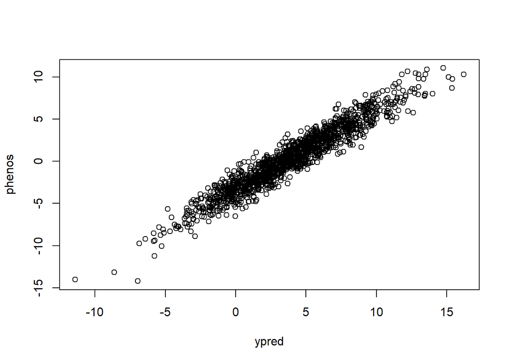

```r
ypred = array(0,N)
# for each individual, predict their phenotypic score as the sum of their genotypes
# times the respective effect size calculated for that snp
for(i in 1:N) {
      ypred[i] = genos[i,assoc] %*% betas[assoc]
}
plot(ypred,phenos)
```

### What is the correlation between the predicted phenotype and the true phenotype?

```r
cor(ypred,phenos)
```

```
##             V1
## [1,] 0.9582865
```

### **BONUS: Test each of the associated SNPs for non-linearity.**

```r
hp = array(0,length(assoc))

for (i in 1:length(assoc)) {
  g = genos[,assoc[i]]
  h = g
  h[h==2]=0
  #Hint: can use anova(lm(?),lm(?)) or summary(lm(?))

  # ? not sure of the below approach I took:
  # testing for whether there is any model performance difference between
  # the model where the only covariate is h (0, and 2 genotypes are combined into 0)
  # vs. the model with just an intercept term (sample mean) as predictor -
  # the idea being if it is an additive model, the average of
  # phenotypes of individuals with genotypes 0, 2 = average of phenotypes individual with genotype 1
  # ... but idk, I feel like there being an imbalanced number of individuals in each h group, might mess with the testing here
  hp[i] <- anova( lm(phenos~h), lm(phenos~1) )$Pr[2] #skip multiple test correction for now
}
hp
```

```
##  [1] 5.096160e-64 2.413307e-12 3.628276e-02 1.364131e-05 6.921153e-02
##  [6] 5.726085e-02 6.022922e-02 3.544787e-26 5.242503e-12 9.406259e-02
```

```r
for (i in 1:length(assoc)) {
  g = genos[,assoc[i]]
  h = g
  h[h==2]=0
  #Hint: can use anova(lm(?),lm(?)) or summary(lm(?))
  # ??? really not sure about this, testing against just intercept
  hp[i] <- anova( lm(phenos~h), lm(phenos~1) )$Pr[2] #skip multiple test correction for now
}
```

### BONUS: Visualize a linear SNP and a non-linear SNP.

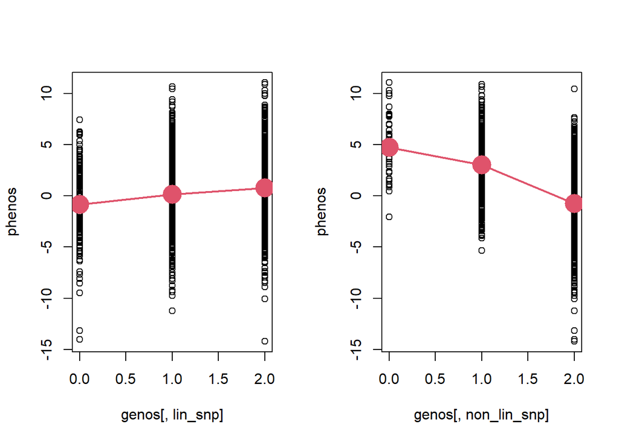

```r
par(mfrow=c(1,2) )

# get linear snp
lin_snp = assoc[which(hp==max(hp))]

# plot linear snp
plot(genos[,lin_snp], phenos)
points( c(0,1,2), tapply(phenos,genos[,lin_snp], mean ), col=2, pch=16, cex=3 )
lines( c(0,1,2), tapply(phenos,genos[,lin_snp], mean ), col=2, lwd=2  )

# non-linear snp

# get non-linear snp
non_lin_snp = assoc[which(hp==min(hp))]

# plot non-linear snp
plot( genos[,non_lin_snp], phenos )
points( c(0,1,2), tapply(phenos, genos[,non_lin_snp], mean ), col=2, pch=16, cex=3 )
lines( c(0,1,2), tapply(phenos, genos[,non_lin_snp], mean ), col=2, lwd=2  )
```

### **Repeat the GWAS to test for recessive rather than additive genetic effects.**

```r
genos2 = genos
genos2[genos<2]=1 # ?? this sets 0,1 as 1 - but i'd be inclined to set 0,1 as 0, and 2 as 1.
pvalues2 = array(0,M)
zscores2 = array(0,M)
betas2 = array(0,M)
for(i in 1:M) {
  g = genos2[,i]
  res = summary(lm(phenos~g))
  zscores2[i] = res$coefficients[2,"t value"]
  pvalues2[i] = res$coefficients[2,"Pr(>|t|)"]
  betas2[i] = res$coefficients[2,"Estimate"]
}
```

### **Are the same SNPs significant or not?**

```r
assoc2 = which(pvalues2<sig_thresh)
assoc2
```

```
## [1] 1 2 3 4 5 6 7 8 9
```

```r
setdiff(assoc2, assoc)
```

```
## integer(0)
```

```r
setdiff(assoc, assoc2)
```

```
## [1] 10
```

### **How did the effect sizes change?**

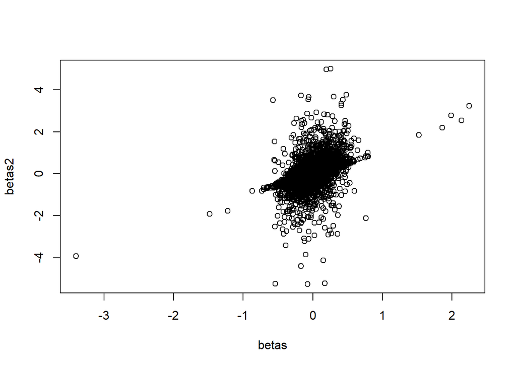

```r
plot(betas,betas2)
```

## PART2: Simulating genotypes with LD.

### **Establish some important simulation parameters.**

```r
N = 1000 #number of individuals
M = 30   #number of non-causal SNPs
gs = matrix(0,nrow=N,ncol=M)
```

### **Simulate a GWAS data set.**

#### First, simulate the causal variant.

```r
set.seed = (42) #set random seed so we all get the same numbers
MAF = 0.5
gC = rbinom(N,1,MAF) #causal variant
```

#### Then, simulate the phenotypes given the causal variant.

```r
beta = 0.3 #association of causal variant
pheno = gC*beta + rnorm(N)
```

#### Generate 10 SNPS in tight LD with the causal SNP.

```r
rho = 0.9
for(i in 1:10) {
  idx = rbinom(N,1,rho)
  gs[,i]=gC*idx+rbinom(N,1,MAF)*(1-idx)
  # test they have the right LD empirically
  cat( 'Observed LD = ', cor( gs[,i], gC ), '\n' )

  # Bonus: prove they have the right LD theoretically

}
```

```
## Observed LD =  0.8880452
## Observed LD =  0.8939582
## Observed LD =  0.9179125
## Observed LD =  0.8778522
## Observed LD =  0.9141014
## Observed LD =  0.8979653
## Observed LD =  0.8998779
## Observed LD =  0.8798611
## Observed LD =  0.8858607
## Observed LD =  0.933954
```

#### Do the same for 10 moderate LD partners (rho=0.6).

```r
rho = 0.6
for(i in 1:10) {
  idx = rbinom(N,1,rho)
  gs[,i+10]=gC*idx+rbinom(N,1,MAF)*(1-idx)
  # test they have the right LD empirically
  cat( 'Observed LD = ', cor( gs[,i+10], gC ), '\n' )
}
```

```
## Observed LD =  0.5845525
## Observed LD =  0.6074589
## Observed LD =  0.621538
## Observed LD =  0.5720193
## Observed LD =  0.5755717
## Observed LD =  0.645478
## Observed LD =  0.5968796
## Observed LD =  0.5829556
## Observed LD =  0.6056355
## Observed LD =  0.5996653
```

Do the same for 10 independent SNPs (rho=0).

```r
rho = 0
for(i in 1:10) {
  idx = rbinom(N,1,rho)
  gs[,i+20]=gC*idx+rbinom(N,1,MAF)*(1-idx)
  # test they have the right LD empirically
  cat( 'Observed LD = ', cor( gs[,i+20], gC ), '\n' )
}
```

```
## Observed LD =  0.03443038
## Observed LD =  0.03098205
## Observed LD =  -0.01248444
## Observed LD =  0.003563303
## Observed LD =  0.02094208
## Observed LD =  -0.00780065
## Observed LD =  0.02007965
## Observed LD =  0.02273756
## Observed LD =  -0.0386284
## Observed LD =  0.004479028
```

### **Run GWAS on the causal variant. Then run GWAS on the other variants. Keep track of the zscores only.**

```r
zsC = summary(lm(pheno~gC))$coef[2,3]
zs = sapply( 1:M, function(i) summary(lm(pheno~gs[,i]))$coef[2,3] )
```

### Visualize the relationship between the mean z-scores at the tag SNPs and the z-score at the causal SNP.

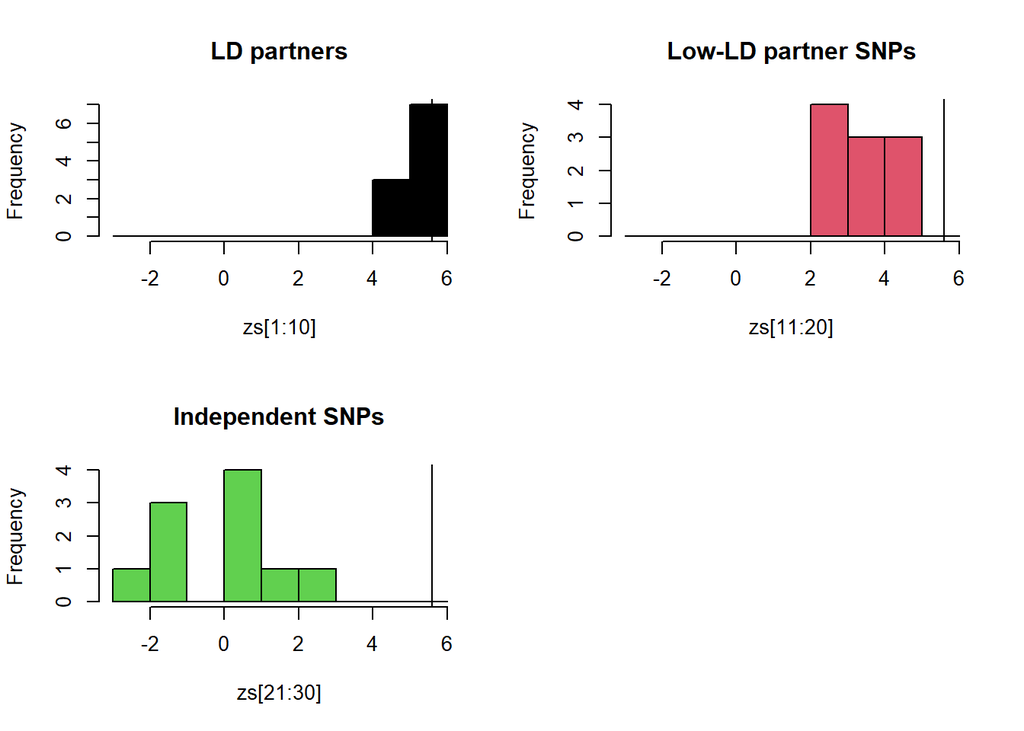

```r
par( mfrow=c(2,2) )
breaks = hist(c(0,zsC,zs),plot=F)$breaks
hist(zs[1:10],breaks=breaks, col=1, main='LD partners')
abline(v=zsC)
hist(zs[11:20],breaks=breaks, col=2, main='Low-LD partner SNPs')
abline(v=zsC)
hist(zs[21:30],breaks=breaks, col=3, main='Independent SNPs')
abline(v=zsC)
```

### **BONUS: Perform LD score regression. First, calculate the LD scores. There should be M+1 of them.**

```r
# ? LD scores are: the sum the squared Pearson correlation coefficients (r²) of a given SNP with all other SNPs
all_gs = cbind(gs, gC)
cor_mat = apply(all_gs, MARGIN = 2, function(geno) cor(geno, gs))
colSums(cor_mat^2 - 1)
```

```
##
## -20.33836 -20.15234 -19.77761 -20.73478 -19.90224 -20.14100 -20.16598 -20.56180
##
## -20.41321 -19.49356 -24.97739 -24.75039 -24.60674 -25.19935 -25.11732 -24.20299
##
## -24.90256 -25.19712 -24.77596 -24.80752 -28.96679 -28.97228 -28.98190 -28.98775
##                                                                    gC
## -28.97904 -28.98204 -28.96506 -28.97703 -28.96928 -28.98547 -18.31626
```

```r
ldscores = colSums(cor_mat^2 - 1)
ldscores
```

```
##
## -20.33836 -20.15234 -19.77761 -20.73478 -19.90224 -20.14100 -20.16598 -20.56180
##
## -20.41321 -19.49356 -24.97739 -24.75039 -24.60674 -25.19935 -25.11732 -24.20299
##
## -24.90256 -25.19712 -24.77596 -24.80752 -28.96679 -28.97228 -28.98190 -28.98775
##                                                                    gC
## -28.97904 -28.98204 -28.96506 -28.97703 -28.96928 -28.98547 -18.31626
```

```r
length(ldscores) # M + 1 = 31 - correct number of ldscores
```

```
## [1] 31
```

### BONUS: Visualize LD score regression.

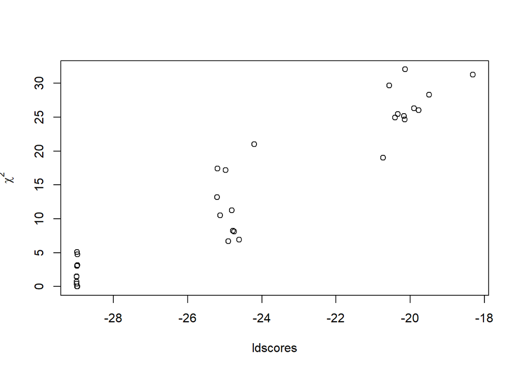

```r
# chi squared test stat is zscore squared
chis = c( zs, zsC )^2
plot(ldscores, chis, ylab=expression(chi^2) )
```

```r
#test for inflation
lambdaGC = median(chis)/0.454
lambdaGC
```

```
## [1] 24.74559
```

### BONUS: Estimate heritability.

```r
adjust_chisq = chis - 1
summary( lm(adjust_chisq ~ ldscores))$coef[2,1] * M/N
```

```
## [1] 0.08262672
```

### BONUS: What is the true heritability?

```r
var(ldscores) / var(adjust_chisq)
```

```
## [1] 0.1188215
```